# Concentration of S&P 500 index

In this data challenge we study how concentrated the S&P 500 is among its constituent companies.

1. The S&P 500 (Standard & Poor’s 500) is a stock market index that tracks the performance of 500 of the largest publicly traded companies in the United States.
2. It covers roughly 80% of the total value of the U.S. stock market.
3. It is a market-capitalization-weighted index. Larger companies have a much bigger impact on its value than smaller components.

We will use:

```r
library(tidyverse)
library(tidyquant)
library(ineq)
```

The three packages have different roles:

```
tidyquant    retrieve the S&P 500 constituents and weights
tidyverse    manipulate and visualize the data
ineq         calculate the Lorenz curve and Gini coefficient
```

Our main questions are:

1. How unequal are the company weights in the S&P 500?
2. How much of the index is represented by its largest companies?
3. What does the Lorenz curve tell us about concentration?
4. What is the Gini coefficient of the S&P 500 weights?

## 1. Get the S&P 500 constituents and their weights

`tq_index()` pulls the current list of S&P 500 constituents together with each company’s index weight directly from an online source.

```r
sp500 <- tq_index("SP500")

sp500 <- sp500 %>%
  filter(!is.na(weight)) %>%
  arrange(desc(weight))

glimpse(sp500)
```

```
## Rows: 504
## Columns: 8
## $ symbol         <chr> "AAPL", "NVDA", "MSFT", "AMZN", "GOOGL", "AVGO", "META"…
## $ company        <chr> "APPLE INC", "NVIDIA CORP", "MICROSOFT CORP", "AMAZON.C…
## $ identifier     <chr> "037833100", "67066G104", "594918104", "023135106", "02…
## $ sedol          <chr> "2046251", "2379504", "2588173", "2000019", "BYVY8G0", …
## $ weight         <dbl> 0.075978107, 0.075244665, 0.057941525, 0.037098364, 0.0…
## $ sector         <chr> "-", "-", "-", "-", "-", "-", "-", "-", "-", "-", "-", …
## $ shares_held    <dbl> 180035605, 298533423, 91596070, 121079589, 72385455, 58…
## $ local_currency <chr> "USD", "USD", "USD", "USD", "USD", "USD", "USD", "USD",…
```

## 2. Summary statistics of the weights

Before looking at inequality measures, let’s get a feel for the distribution of weights: the mean, median, min, max, and how many companies make up the index.

```r
sp500 %>%
  summarise(
    n_companies = n(),
    total_weight = sum(weight),
    mean_weight = mean(weight),
    median_weight = median(weight),
    min_weight = min(weight),
    max_weight = max(weight)
  )
```

```
## # A tibble: 1 × 6
##   n_companies total_weight mean_weight median_weight   min_weight max_weight
##         <int>        <dbl>       <dbl>         <dbl>        <dbl>      <dbl>
## 1         504            1     0.00198      0.000680 0.0000000300     0.0760
```

Weight is expressed as a fraction (or percent, depending on the source) of the total index value. If `total_weight` is close to 1 (or 100), that confirms weights sum to the whole index.

## 3. The top 10 companies by weight

Since the index is market-cap weighted, a handful of giant companies should account for a disproportionate share of the index value.

```r
top10 <- sp500 %>%
  slice_max(weight, n = 10) %>%
  select(symbol, company, weight)

top10
```

```
## # A tibble: 10 × 3
##    symbol company                    weight
##    <chr>  <chr>                       <dbl>
##  1 AAPL   APPLE INC                  0.0760
##  2 NVDA   NVIDIA CORP                0.0752
##  3 MSFT   MICROSOFT CORP             0.0579
##  4 AMZN   AMAZON.COM INC             0.0371
##  5 GOOGL  ALPHABET INC CL A          0.0252
##  6 AVGO   BROADCOM INC               0.0236
##  7 META   META PLATFORMS INC CLASS A 0.0206
##  8 GOOG   ALPHABET INC CL C          0.0203
##  9 TSLA   TESLA INC                  0.0175
## 10 LLY    ELI LILLY + CO             0.0174
```

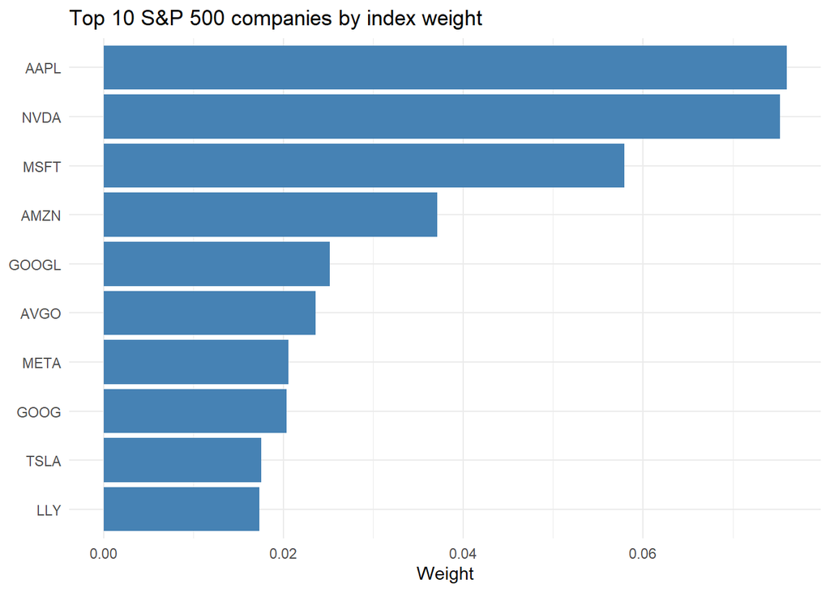

```r
ggplot(top10, aes(x = reorder(symbol, weight), y = weight)) +
  geom_col(fill = "steelblue") +
  coord_flip() +
  labs(
    title = "Top 10 S&P 500 companies by index weight",
    x = NULL,
    y = "Weight"
  ) +
  theme_minimal()
```

## 4. Cumulative weight: how much of the index is in the top N companies?

We sort companies by weight (largest first) and compute the cumulative sum. This tells us, e.g., what fraction of the index value the top 10, top 50, or top 100 companies represent.

```r
sp500_cum <- sp500 %>%
  arrange(desc(weight)) %>%
  mutate(
    rank = row_number(),
    cum_weight = cumsum(weight) / sum(weight)
  )

sp500_cum %>%
  filter(rank %in% c(1, 5, 10, 25, 50, 100, 200, 500)) %>%
  select(rank, cum_weight)
```

```
## # A tibble: 8 × 2
##    rank cum_weight
##   <int>      <dbl>
## 1     1     0.0760
## 2     5     0.271
## 3    10     0.371
## 4    25     0.517
## 5    50     0.626
## 6   100     0.746
## 7   200     0.872
## 8   500     1.000
```

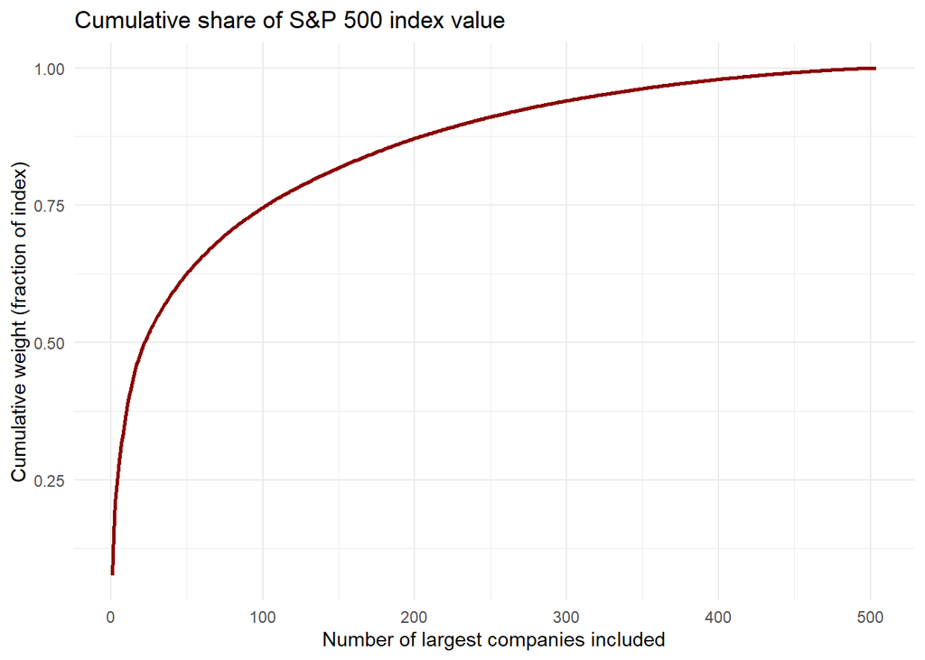

```r
ggplot(sp500_cum, aes(x = rank, y = cum_weight)) +
  geom_line(color = "darkred", linewidth = 1) +
  labs(
    title = "Cumulative share of S&P 500 index value",
    x = "Number of largest companies included",
    y = "Cumulative weight (fraction of index)"
  ) +
  theme_minimal()
```

## 5. The Lorenz curve

The Lorenz curve plots the cumulative share of total weight held by the bottom X% of companies (ordered from smallest to largest). A perfectly equal index (every company has the same weight) would produce a straight 45-degree line. The more the curve bows below that line, the more concentrated the index is.

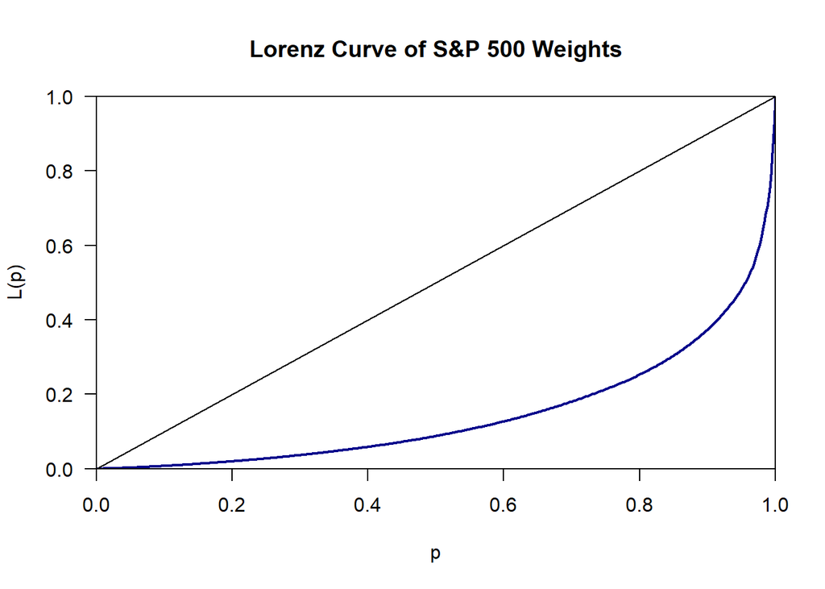

```r
Lc_sp500 <- Lc(sp500$weight)

plot(Lc_sp500,
     main = "Lorenz Curve of S&P 500 Weights",
     col = "darkblue", lwd = 2)
```

## 6. The Gini coefficient

The Gini coefficient summarizes the Lorenz curve in a single number between 0 and 1: 0 means perfect equality (every company has the same weight), 1 means maximal inequality (one company has all the weight).

```r
gini_sp500 <- Gini(sp500$weight)
gini_sp500
```

```
## [1] 0.7061881
```

## 7. Conclusions

```r
cat(
  "Number of companies in the index:", nrow(sp500), "\n",
  "Top 10 companies account for:", scales::percent(sum(top10$weight)), "of the index\n",
  "Gini coefficient of weights:", round(gini_sp500, 3), "\n"
)
```

```
## Number of companies in the index: 504
##  Top 10 companies account for: 37% of the index
##  Gini coefficient of weights: 0.706
```

- The Gini coefficient (close to 1 = high inequality, close to 0 = low inequality) tells us quantitatively how concentrated the index is.
- The cumulative weight table/plot shows that a relatively small number of “mega-cap” companies account for a large share of the index’s total value, even though the index nominally has ~500 constituents.
- The Lorenz curve visualizes this same imbalance: the area between the curve and the 45-degree line of perfect equality is proportional to the Gini coefficient.